# Python Statistical Analysis in Practice — 02: Descriptive Statistics & EDA

## Part 7: Why You Must Always Visualise — Anscombe's Quartet

In 1973, statistician Francis Anscombe constructed four datasets that are **nearly identical in every summary statistic** yet look completely different when plotted. This is one of the most important demonstrations in statistics.

> **Lesson:** Summary statistics are a compression of information. They can hide structure that is obvious in a plot.

```python
# Anscombe's Quartet — exact values
anscombe = {
    'I':   {'x': [10,8,13,9,11,14,6,4,12,7,5],
             'y': [8.04,6.95,7.58,8.81,8.33,9.96,7.24,4.26,10.84,4.82,5.68]},
    'II':  {'x': [10,8,13,9,11,14,6,4,12,7,5],
             'y': [9.14,8.14,8.74,8.77,9.26,8.10,6.13,3.10,9.13,7.26,4.74]},
    'III': {'x': [10,8,13,9,11,14,6,4,12,7,5],
             'y': [7.46,6.77,12.74,7.11,7.81,8.84,6.08,5.39,8.15,6.42,5.73]},
    'IV':  {'x': [8,8,8,8,8,8,8,19,8,8,8],
             'y': [6.58,5.76,7.71,8.84,8.47,7.04,5.25,12.50,5.56,7.91,6.89]},
}

# Compute summary stats for each
print(f'{"Dataset":<10} {"Mean X":>8} {"Mean Y":>8} {"Var X":>8} {"Var Y":>8} {"Corr(X,Y)":>10} {"R²":>6}')
print('-' * 65)
for name, d in anscombe.items():
    x, y = np.array(d['x']), np.array(d['y'])
    r, _ = stats.pearsonr(x, y)
    b1 = r * y.std(ddof=1) / x.std(ddof=1)
    b0 = y.mean() - b1 * x.mean()
    print(f'{name:<10} {x.mean():>8.2f} {y.mean():>8.2f} {x.var(ddof=1):>8.2f} '
          f'{y.var(ddof=1):>8.2f} {r:>10.3f} {r**2:>6.3f}')

print()
print('All four datasets have:')
print('  Nearly identical means, variances, correlation, and regression line.')
print('  → If you only looked at the numbers, you would conclude they are the same.')
```

```
Dataset      Mean X   Mean Y    Var X    Var Y  Corr(X,Y)     R²
-----------------------------------------------------------------
I              9.00     7.50    11.00     4.13      0.816  0.667
II             9.00     7.50    11.00     4.13      0.816  0.666
III            9.00     7.50    11.00     4.12      0.816  0.666
IV             9.00     7.50    11.00     4.12      0.817  0.667

All four datasets have:
  Nearly identical means, variances, correlation, and regression line.
  → If you only looked at the numbers, you would conclude they are the same.
```

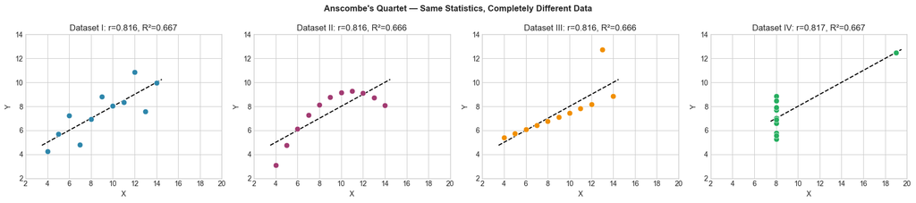

```
Dataset I  : Linear relationship with random scatter — the "normal" case.
Dataset II : Perfectly curved (quadratic) — linear fit is wrong model entirely.
Dataset III: All points on a line EXCEPT one outlier — outlier drives the fit.
Dataset IV : All X identical except one — correlation driven by a single lever point.

→ ALWAYS plot your data. Summary statistics lie by omission.
```

```python
# Now visualise — the truth emerges
fig, axes = plt.subplots(1, 4, figsize=(18, 4))
fig.suptitle("Anscombe's Quartet — Same Statistics, Completely Different Data",
             fontsize=12, fontweight='bold')

colors_a = [COLORS['primary'], COLORS['secondary'], COLORS['accent'], COLORS['success']]

for ax, (name, d), color in zip(axes, anscombe.items(), colors_a):
    x, y = np.array(d['x']), np.array(d['y'])
    ax.scatter(x, y, color=color, s=60, zorder=3, edgecolors='white', linewidth=0.5)

    # Regression line
    b1 = stats.pearsonr(x, y)[0] * y.std(ddof=1) / x.std(ddof=1)
    b0 = y.mean() - b1 * x.mean()
    x_line = np.linspace(x.min()-0.5, x.max()+0.5, 100)
    ax.plot(x_line, b0 + b1*x_line, color='black', lw=1.5, linestyle='--', label='Fit')

    r, _ = stats.pearsonr(x, y)
    ax.set_title(f'Dataset {name}: r={r:.3f}, R²={r**2:.3f}')
    ax.set_xlabel('X'); ax.set_ylabel('Y')
    ax.set_xlim(2, 20); ax.set_ylim(2, 14)

plt.tight_layout()
plt.show()

print('Dataset I  : Linear relationship with random scatter — the "normal" case.')
print('Dataset II : Perfectly curved (quadratic) — linear fit is wrong model entirely.')
print('Dataset III: All points on a line EXCEPT one outlier — outlier drives the fit.')
print('Dataset IV : All X identical except one — correlation driven by a single lever point.')
print()
print('→ ALWAYS plot your data. Summary statistics lie by omission.')
```

## Part 8: Bivariate EDA — Two Variables Together

### 8.1 Scatter Plot: Your First Move with Two Continuous Variables

```
Simulated data: test_score = 30 + 7.5 × study_hours + ε  (ε ~ N(0, 10))
       study_hours  test_score
count      300.000     300.000
mean         4.500      62.680
std          1.930      17.190
min          1.020      22.700
25%          2.860      50.260
50%          4.350      61.790
75%          6.150      75.610
max          7.990     118.940
```

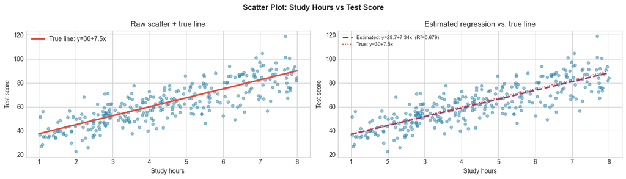

```
Estimated slope = 7.340  (true = 7.5)
Estimated intercept = 29.678  (true = 30)
R² = 0.679
```

```python
# Simulate a dataset: test score vs study hours, with some noise
n = 300
study_hours = RNG.uniform(1, 8, n)
true_slope  = 7.5   # each extra hour → +7.5 points
true_int    = 30
noise       = RNG.normal(0, 10, n)
test_score  = true_int + true_slope * study_hours + noise

df_study = pd.DataFrame({'study_hours': study_hours, 'test_score': test_score})

print('Simulated data: test_score = 30 + 7.5 × study_hours + ε  (ε ~ N(0, 10))')
print(df_study.describe().round(2).to_string())

fig, axes = plt.subplots(1, 2, figsize=(14, 4))
fig.suptitle('Scatter Plot: Study Hours vs Test Score', fontsize=12, fontweight='bold')

# Basic scatter
axes[0].scatter(df_study.study_hours, df_study.test_score,
                color=COLORS['primary'], alpha=0.5, s=20)
# True line
x_line = np.linspace(1, 8, 100)
axes[0].plot(x_line, true_int + true_slope * x_line,
             color=COLORS['danger'], lw=2.5, label=f'True line: y=30+7.5x')
axes[0].set_xlabel('Study hours'); axes[0].set_ylabel('Test score')
axes[0].set_title('Raw scatter + true line')
axes[0].legend()

# With regression line estimated from data
from scipy.stats import linregress
slope, intercept, r_val, p_val, se = linregress(df_study.study_hours, df_study.test_score)
axes[1].scatter(df_study.study_hours, df_study.test_score,
                color=COLORS['primary'], alpha=0.5, s=20)
axes[1].plot(x_line, intercept + slope * x_line,
             color=COLORS['secondary'], lw=2.5, linestyle='--',
             label=f'Estimated: y={intercept:.1f}+{slope:.2f}x  (R²={r_val**2:.3f})')
axes[1].plot(x_line, true_int + true_slope * x_line,
             color=COLORS['danger'], lw=1.5, linestyle=':',
             label=f'True: y=30+7.5x')
axes[1].set_xlabel('Study hours'); axes[1].set_ylabel('Test score')
axes[1].set_title('Estimated regression vs. true line')
axes[1].legend(fontsize=8)
plt.tight_layout()
plt.show()

print(f'\nEstimated slope = {slope:.3f}  (true = 7.5)')
print(f'Estimated intercept = {intercept:.3f}  (true = 30)')
print(f'R² = {r_val**2:.3f}')
```

### 8.2 Pearson vs Spearman Correlation

| Correlation | What it measures | Requires | Robust to outliers? |
| --- | --- | --- | --- |
| **Pearson r** | Linear relationship | Continuous, roughly normal | No |
| **Spearman ρ** | Monotonic relationship (any direction) | Ordinal or continuous | Yes |

> **When to use Spearman:** skewed data, ordinal variables, when outliers are present, or when the relationship is monotone but non-linear.

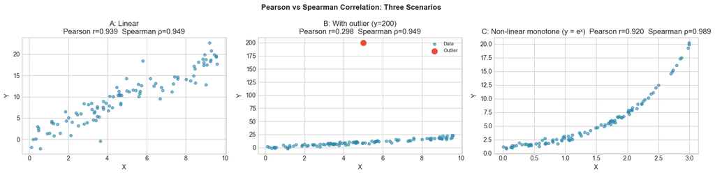

```
Case A: Both agree — linear = monotone, no outliers.
Case B: Pearson drops sharply, Spearman barely changes → outlier exposed.
Case C: Spearman ≈ 1.0 (perfect monotone), Pearson misses the exponential curve.
```

```python
# Case A: Pearson and Spearman agree (linear, no outliers)
# Case B: They disagree (outlier distorts Pearson)
# Case C: Non-linear but monotone (Spearman wins)

fig, axes = plt.subplots(1, 3, figsize=(16, 4))
fig.suptitle('Pearson vs Spearman Correlation: Three Scenarios', fontsize=12, fontweight='bold')

x_base = RNG.uniform(0, 10, 100)

# Case A: linear
y_A = 2 * x_base + RNG.normal(0, 2, 100)
pA, _ = stats.pearsonr(x_base, y_A)
sA, _ = stats.spearmanr(x_base, y_A)
axes[0].scatter(x_base, y_A, color=COLORS['primary'], alpha=0.6, s=20)
axes[0].set_title(f'A: Linear\nPearson r={pA:.3f}  Spearman ρ={sA:.3f}')
axes[0].set_xlabel('X'); axes[0].set_ylabel('Y')

# Case B: one extreme outlier
x_B = np.append(x_base, 5)
y_B = np.append(2 * x_base + RNG.normal(0, 2, 100), 200)  # outlier at y=200
pB, _ = stats.pearsonr(x_B, y_B)
sB, _ = stats.spearmanr(x_B, y_B)
axes[1].scatter(x_B[:-1], y_B[:-1], color=COLORS['primary'], alpha=0.6, s=20, label='Data')
axes[1].scatter(x_B[-1:], y_B[-1:], color=COLORS['danger'], s=80, zorder=5, label='Outlier')
axes[1].set_title(f'B: With outlier (y=200)\nPearson r={pB:.3f}  Spearman ρ={sB:.3f}')
axes[1].set_xlabel('X'); axes[1].set_ylabel('Y')
axes[1].legend(fontsize=8)

# Case C: non-linear monotone (exponential)
x_C = RNG.uniform(0, 3, 100)
y_C = np.exp(x_C) + RNG.normal(0, 0.3, 100)
pC, _ = stats.pearsonr(x_C, y_C)
sC, _ = stats.spearmanr(x_C, y_C)
axes[2].scatter(x_C, y_C, color=COLORS['primary'], alpha=0.6, s=20)
axes[2].set_title(f'C: Non-linear monotone (y = eˣ)  Pearson r={pC:.3f}  Spearman ρ={sC:.3f}')
axes[2].set_xlabel('X'); axes[2].set_ylabel('Y')

plt.tight_layout()
plt.show()

print('Case A: Both agree — linear = monotone, no outliers.')
print('Case B: Pearson drops sharply, Spearman barely changes → outlier exposed.')
print('Case C: Spearman ≈ 1.0 (perfect monotone), Pearson misses the exponential curve.')
```

## Part 9: Multivariate Overview — Pair Plots and Heatmaps

When you have more than two variables, a **pair plot** (scatter matrix) and a **correlation heatmap** give the fastest overview of all pairwise relationships.

```python
# Simulate a 4-variable dataset with planted correlations
n = 400

x1 = RNG.normal(50, 10, n)          # IQ score (synthetic)
x2 = 0.6 * x1 + RNG.normal(0, 8, n) # reading score (moderate + correlation with IQ)
x3 = 0.8 * x1 + RNG.normal(0, 5, n) # math score (high + correlation with IQ)
x4 = RNG.normal(30, 7, n)            # unrelated variable (study hours — independent)

df_multi = pd.DataFrame({
    'IQ':    x1,
    'Reading': x2,
    'Math':  x3,
    'Study_hrs': x4,
})

print('Planted correlations:')
print('  IQ ↔ Reading  : ~0.6 (moderate)')
print('  IQ ↔ Math     : ~0.8 (strong)')
print('  IQ ↔ Study_hrs: ~0.0 (independent)')
print()
print('Sample correlation matrix:')
print(df_multi.corr(method='pearson').round(3).to_string())
```

```
Planted correlations:
  IQ ↔ Reading  : ~0.6 (moderate)
  IQ ↔ Math     : ~0.8 (strong)
  IQ ↔ Study_hrs: ~0.0 (independent)

Sample correlation matrix:
             IQ  Reading  Math  Study_hrs
IQ        1.000    0.594 0.840      0.012
Reading   0.594    1.000 0.484      0.113
Math      0.840    0.484 1.000      0.015
Study_hrs 0.012    0.113 0.015      1.000
```

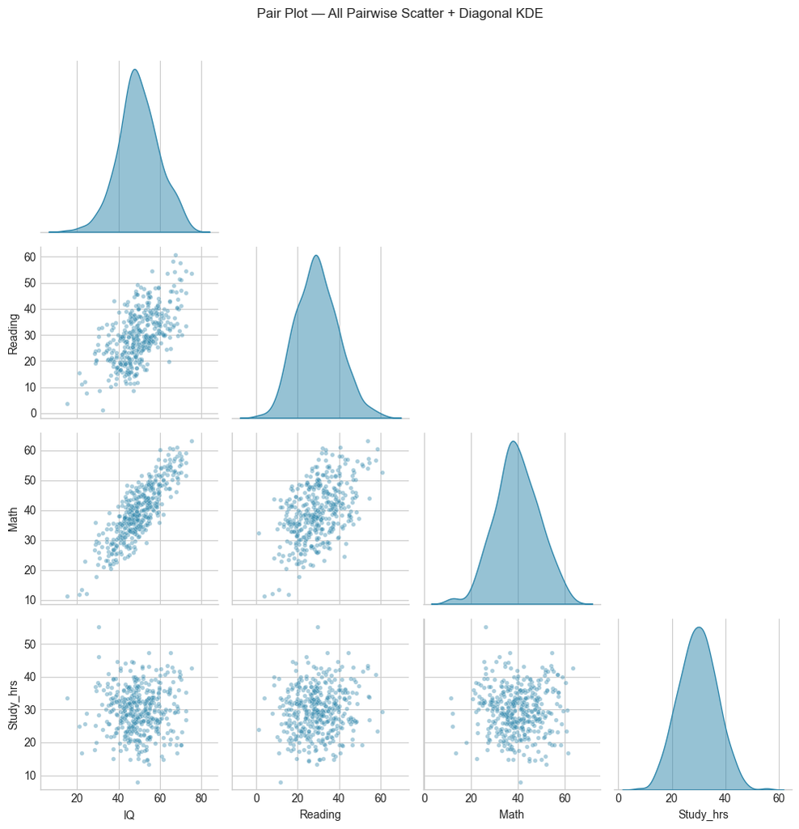

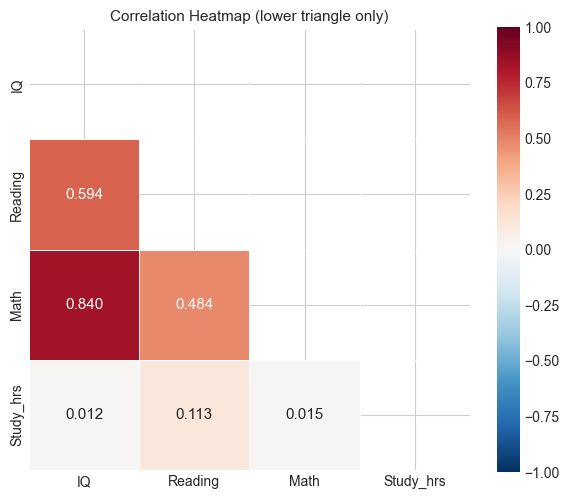

```
The heatmap confirms what we planted:
  IQ–Math:    r≈0.8 (dark red, strong positive)
  IQ–Reading: r≈0.6 (orange, moderate positive)
  Study–*:    r≈0.0 (white, no relationship)
```

```python
# Pair plot
g = sns.pairplot(df_multi, diag_kind='kde', corner=True,
                 plot_kws={'alpha': 0.4, 's': 15, 'color': COLORS['primary']},
                 diag_kws={'color': COLORS['primary'], 'fill': True, 'alpha': 0.5})
g.figure.suptitle('Pair Plot — All Pairwise Scatter + Diagonal KDE', y=1.02, fontsize=12)
plt.tight_layout()
plt.show()

# Heatmap
fig, ax = plt.subplots(figsize=(6, 5))
corr_matrix = df_multi.corr(method='pearson')
mask = np.triu(np.ones_like(corr_matrix, dtype=bool))  # upper triangle = redundant
sns.heatmap(corr_matrix, annot=True, fmt='.3f', cmap='RdBu_r',
            vmin=-1, vmax=1, center=0, ax=ax, mask=mask,
            square=True, linewidths=0.5,
            annot_kws={'size': 11})
ax.set_title('Correlation Heatmap (lower triangle only)', fontsize=11)
plt.tight_layout()
plt.show()

print('The heatmap confirms what we planted:')
print('  IQ–Math:    r≈0.8 (dark red, strong positive)')
print('  IQ–Reading: r≈0.6 (orange, moderate positive)')
print('  Study–*:    r≈0.0 (white, no relationship)')
```

## Part 10: The Full EDA Pipeline — Applied to a Planted Dataset

We now assemble everything into a structured, reproducible EDA workflow. We generate a dataset with **known structure** — groups, outliers, a skewed variable, and planted correlations — then run the full pipeline to verify we can recover every feature we planted.

**Planted structure:**

| Feature | What we planted |
| --- | --- |
| Two groups | Group A ~ Normal(65, 8), Group B ~ Normal(75, 10) |
| Skewed variable | Income ~ LogNormal(10.8, 0.5) |
| Outliers | 5 extreme values injected into Group A income |
| Correlation | age ↔ blood_pressure: r ≈ 0.55 |

```python
# ── Generate the dataset ──────────────────────────────────────────────────────
np.random.seed(42)
n_A, n_B = 150, 150

# Group A
age_A    = RNG.normal(35, 8, n_A).clip(18, 70).round(0)
bp_A     = 80 + 0.55 * (age_A - age_A.mean()) / age_A.std() * 15 + RNG.normal(0, 12, n_A)
income_A = RNG.lognormal(10.8, 0.5, n_A) / 1000  # in thousand yuan
score_A  = RNG.normal(65, 8, n_A)

# Group B
age_B    = RNG.normal(45, 10, n_B).clip(18, 75).round(0)
bp_B     = 80 + 0.55 * (age_B - age_B.mean()) / age_B.std() * 15 + RNG.normal(0, 14, n_B)
income_B = RNG.lognormal(11.0, 0.6, n_B) / 1000
score_B  = RNG.normal(75, 10, n_B)

# Inject outliers
income_A[:5] = [500, 600, 550, 480, 520]

df_full = pd.DataFrame({
    'group':        ['A'] * n_A + ['B'] * n_B,
    'age':          np.concatenate([age_A, age_B]),
    'blood_pressure': np.concatenate([bp_A, bp_B]),
    'income_k':     np.concatenate([income_A, income_B]),
    'test_score':   np.concatenate([score_A, score_B]),
})

print(f'Dataset shape: {df_full.shape}')
print(f'Groups: {df_full.group.value_counts().to_dict()}')
print()
print('=== Step 1: Data shape and types ===')
print(df_full.dtypes.to_string())
print()
print('=== Missing values ===')
print(df_full.isnull().sum().to_string())
```

```
Dataset shape: (300, 5)
Groups: {'A': 150, 'B': 150}

=== Step 1: Data shape and types ===
group              object
age               float64
blood_pressure    float64
income_k          float64
test_score        float64

=== Missing values ===
group             0
age               0
blood_pressure    0
income_k          0
test_score        0
```

```python
# ── Step 2: Univariate summaries ─────────────────────────────────────────────
print('=== Step 2: Summary statistics (all numeric variables) ===')
desc = df_full.describe().round(2)

# Add skewness and kurtosis
desc.loc['skewness'] = df_full.select_dtypes('number').apply(stats.skew).round(3)
desc.loc['kurtosis'] = df_full.select_dtypes('number').apply(stats.kurtosis).round(3)
print(desc.to_string())

print()
print('Observations:')
print(f'  income_k skewness = {stats.skew(df_full.income_k):.2f} → highly right-skewed (outliers)')
print(f'  test_score skewness = {stats.skew(df_full.test_score):.2f} → fairly symmetric')
print(f'  income_k max = {df_full.income_k.max():.0f}k → clearly our injected outliers')
```

```
=== Step 2: Summary statistics (all numeric variables) ===
             age  blood_pressure  income_k  test_score
count    300.000         300.000   300.000     300.000
mean      38.940          79.450    71.370      70.380
std       10.000          14.970    72.620      10.070
min       18.000          32.800    10.370      47.220
25%       32.000          69.310    37.190      63.080
50%       38.000          79.960    52.640      69.690
75%       46.000          89.270    77.510      76.940
max       68.000         117.990   600.000     103.010
skewness   0.285          -0.191     4.615       0.178
kurtosis  -0.287           0.001    25.915      -0.072

Observations:
  income_k skewness = 4.61 → highly right-skewed (outliers)
  test_score skewness = 0.18 → fairly symmetric
  income_k max = 600k → clearly our injected outliers
```

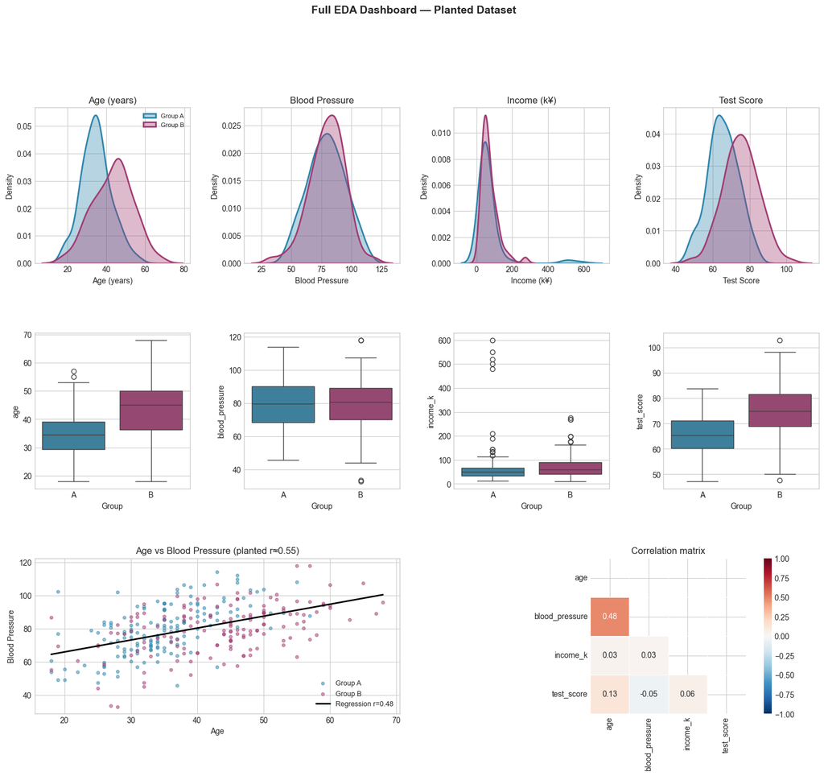

```python
# ── Step 3: Full visualisation dashboard ─────────────────────────────────────
fig = plt.figure(figsize=(18, 14))
fig.suptitle('Full EDA Dashboard — Planted Dataset', fontsize=14, fontweight='bold', y=1.01)

gs = gridspec.GridSpec(3, 4, figure=fig, hspace=0.45, wspace=0.35)

# Row 0: univariate distributions
for col_idx, (var, label) in enumerate(zip(
    ['age', 'blood_pressure', 'income_k', 'test_score'],
    ['Age (years)', 'Blood Pressure', 'Income (k¥)', 'Test Score']
)):
    ax = fig.add_subplot(gs[0, col_idx])
    for grp, color in [('A', COLORS['primary']), ('B', COLORS['secondary'])]:
        subset = df_full[df_full.group == grp][var]
        sns.kdeplot(subset, ax=ax, color=color, fill=True, alpha=0.35,
                    linewidth=2, label=f'Group {grp}')
    ax.set_title(label); ax.set_xlabel(label); ax.set_ylabel('Density')
    if col_idx == 0: ax.legend(fontsize=8)

# Row 1: boxplots by group
for col_idx, var in enumerate(['age', 'blood_pressure', 'income_k', 'test_score']):
    ax = fig.add_subplot(gs[1, col_idx])
    sns.boxplot(data=df_full, x='group', y=var, ax=ax,
                palette=[COLORS['primary'], COLORS['secondary']])
    ax.set_xlabel('Group')

# Row 2, left: scatter age vs BP
ax_scatter = fig.add_subplot(gs[2, :2])
for grp, color in [('A', COLORS['primary']), ('B', COLORS['secondary'])]:
    sub = df_full[df_full.group == grp]
    ax_scatter.scatter(sub.age, sub.blood_pressure, s=15, alpha=0.5,
                       color=color, label=f'Group {grp}')
# Add overall regression line
slope_bp, int_bp, r_bp, *_ = linregress(df_full.age, df_full.blood_pressure)
x_arr = np.linspace(df_full.age.min(), df_full.age.max(), 100)
ax_scatter.plot(x_arr, int_bp + slope_bp * x_arr, color='black', lw=2,
                label=f'Regression r={r_bp:.2f}')
ax_scatter.set_xlabel('Age'); ax_scatter.set_ylabel('Blood Pressure')
ax_scatter.set_title('Age vs Blood Pressure (planted r≈0.55)')
ax_scatter.legend(fontsize=9)

# Row 2, right: heatmap
ax_heat = fig.add_subplot(gs[2, 2:])
corr_m = df_full.select_dtypes('number').corr()
mask_tri = np.triu(np.ones_like(corr_m, dtype=bool))
sns.heatmap(corr_m, annot=True, fmt='.2f', cmap='RdBu_r',
            vmin=-1, vmax=1, center=0, ax=ax_heat,
            mask=mask_tri, square=True, linewidths=0.5,
            annot_kws={'size': 10})
ax_heat.set_title('Correlation matrix')

plt.show()
```

```python
# ── Step 4: Verify what we planted ───────────────────────────────────────────
from scipy.stats import ttest_ind, mannwhitneyu

print('=== Step 4: Verification ===')
print()

# Group means
for grp, planted in [('A', 65), ('B', 75)]:
    obs = df_full[df_full.group == grp]['test_score'].mean()
    print(f'Group {grp} test_score: planted μ={planted}, observed mean={obs:.2f}')

print()

# Age–BP correlation
r_age_bp, p_age_bp = stats.pearsonr(df_full.age, df_full.blood_pressure)
print(f'age–blood_pressure correlation: r={r_age_bp:.3f}  (planted ≈ 0.55)  p={p_age_bp:.4f}')

print()

# Income skewness
skew_income = stats.skew(df_full.income_k)
print(f'income_k skewness = {skew_income:.2f}  (expected >> 1 due to injected outliers)')

print()

# Outlier detection
q1, q3 = df_full.income_k.quantile([0.25, 0.75])
iqr_val = q3 - q1
outliers_detected = df_full[df_full.income_k > q3 + 1.5 * iqr_val]
print(f'Income outliers detected (IQR method): {len(outliers_detected)} rows')
print(f'  Outlier values: {sorted(outliers_detected.income_k.round(0).tolist(), reverse=True)[:8]}')
print(f'  (We injected 5 values at 480–600k; IQR method found {len(outliers_detected)} flags)')
```

```
=== Step 4: Verification ===

Group A test_score: planted μ=65, observed mean=65.57
Group B test_score: planted μ=75, observed mean=75.20

age–blood_pressure correlation: r=0.480  (planted ≈ 0.55)  p=0.0000

income_k skewness = 4.61  (expected >> 1 due to injected outliers)

Income outliers detected (IQR method): 21 rows
  Outlier values: [600.0, 550.0, 520.0, 500.0, 480.0, 275.0, 269.0, 269.0]
  (We injected 5 values at 480–600k; IQR method found 21 flags)
```

## Summary

| Concept | Key takeaway |
| --- | --- |
| Mean vs Median | Use median (+ IQR) for skewed data; mean for symmetric |
| Std vs IQR | IQR is robust to outliers; std is not |
| CV | Use to compare relative variability across different-scale groups |
| Skewness | \|skew\| > 1 → consider log transform or non-parametric methods |
| Kurtosis | Excess > 0 → fat tails → normality tests may fail |
| Visualization | Always use histograms, KDE, boxplots before any test |
| Bimodality | Boxplot hides it; violin and strip plots reveal it |
| Outliers | Z-score (fast) vs IQR Tukey fences (robust); investigate before removing |
| Anscombe | Same statistics ≠ same data. **Always plot.** |
| Pearson vs Spearman | Spearman is robust to outliers and non-linear monotone relationships |
| Pair plot / heatmap | Fast multivariate overview before modelling |

### The EDA Checklist

```
1. Check shape: df.shape, df.dtypes, df.isnull().sum()
2. Summary stats: df.describe() + skewness + kurtosis
3. Univariate: histogram/KDE + boxplot for each variable
4. Outliers: boxplot whiskers, z-score, or IQR method
5. Bivariate: scatter plots for key pairs + correlation matrix
6. Group comparison: KDE or violin by category variable
7. Heatmap: correlation matrix for all numerical variables
8. Decide: transform skewed variables? Remove errors? Investigate outliers?
```

**Next lecture →** Lecture 03: Probability Distributions in Depth — PDF, CDF, quantile functions, and how to choose the right distribution for your data.

*Python Statistical Analysis in Practice — Lecture 02*  
*Author: Jason JJ Li · PKU Institute of Population Research*